# Conley Fisheries Case

Ali Ladha

2024-10-05

```r
#Loading Tidyverse package
library(tidyverse)
#Earning simulation at Rockport
number <- 1000

# Empty data frame for 1000 simulated days
empty_data <- data.frame(day = seq(1:number),
                demand = NA, # demand in Rockport
                quantity = NA, # quantity sold
                price = NA, # price per pound
                cost = 10000, # cost of daily operations
                earnings = NA)

head(empty_data)
```

```
##   day demand quantity price  cost earnings
## 1   1     NA       NA    NA 10000       NA
## 2   2     NA       NA    NA 10000       NA
## 3   3     NA       NA    NA 10000       NA
## 4   4     NA       NA    NA 10000       NA
## 5   5     NA       NA    NA 10000       NA
## 6   6     NA       NA    NA 10000       NA
```

```r
set.seed(123)
sim <- empty_data %>%
  mutate(demand = sample(x = c(0, 1000, 2000, 3000, 4000, 5000, 6000),
                         size = number,
                         replace = TRUE,
                         prob = c(0.02, 0.03, 0.05, 0.08, 0.33, 0.29, 0.20)),
         quantity = ifelse(demand > 3500, 3500, demand),
         price = rnorm(n = number, mean = 3.65, sd = 0.2),
         earnings = price * quantity - cost)

head(sim, 10)
```

```
##    day demand quantity    price  cost   earnings
## 1    1   4000     3500 3.529621 10000  2353.6750
## 2    2   6000     3500 3.451260 10000  2079.4110
## 3    3   5000     3500 3.855357 10000  3493.7495
## 4    4   3000     3000 3.800212 10000  1400.6368
## 5    5   2000     2000 3.348167 10000 -3303.6666
## 6    6   4000     3500 3.630971 10000  2708.3968
## 7    7   5000     3500 3.470810 10000  2147.8365
## 8    8   3000     3000 3.235850 10000  -292.4506
## 9    9   5000     3500 3.680024 10000  2880.0841
## 10  10   5000     3500 3.634158 10000  2719.5518
```

## Q1

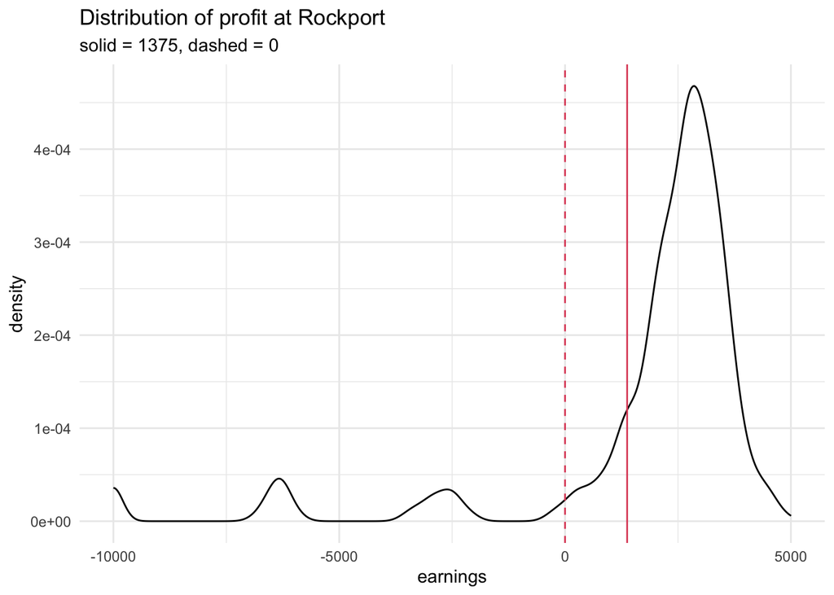

```r
ggplot(data = sim, aes(earnings)) +
  geom_density() +
  geom_vline(xintercept = 1375, col = 2) +
  geom_vline(xintercept = 0, col = 2, lty = 2) +
  theme_minimal() +
  labs(title = 'Distribution of profit at Rockport',
       subtitle = 'solid = 1375, dashed = 0')
```

Based on the density plot created, the mean earnings of Rockport is higher than the mean earnings of Gloucester. Furthermore the graph indicates that Rockport also has losses in earnings, but it also has more potential for higher profits.

## Q2

```r
#Earnings at Gloucester are fixed at $1375 ($3.25 x 3500 - $10,000). What is P(F > 1375) at Rockport? Write down the answer.

mean(sim$earnings > 1375)
```

```
## [1] 0.826
```

## Q3

```r
#What is the probability that Mr. Conley will lose money? We can express this as P(F < 0). Write down the answer.

mean(sim$earnings < 0)
```

```
## [1] 0.099
```

The probability that Mr. Conley will lose money is approximetely 9.9% at Rockport.

## Q4

```r
#What is the mean of F? Write down the answer.

mean(sim$earning)
```

```
## [1] 1879.699
```

The average/mean earnings at Rockport is $1879.70

## Q5

```r
#Earnings calculation based on simulation


rockport_average_earnings <- mean(sim$earning) * 50
rockport_average_earnings
```

```
## [1] 93984.96
```

```r
gloucester_earnings <- 1375 * 50
gloucester_earnings
```

```
## [1] 68750
```

```r
difference_per_boat <- rockport_average_earnings - gloucester_earnings
difference_per_boat
```

```
## [1] 25234.96
```

```r
#What is your advice to Mr. Conley? Write one paragraph in which you argue a position. In your answer please incorporate the quantitative details from your simulation, and consider in particular the trade-off between risk and reward.
```

Rockport has higher earnings than the fixed earnings achievable from Gloucester. On average the earnings from Rockport is $1879.70 whereas the earnings from Gloucester is $1375. This surplus in earnings comes with a risk where there is a 9.9% chance of a loss in Rockport due to lack of demand. In comparision Gloucester does not have this risk. Rockport is expected to beat the earnings from Gloucester 82.6% of the time. It is therefore advisable to use Rockport instead of Gloucester. The difference in earnings per boat is an additional $504.70 on average. Whereas the difference per fleet (50 boats) is $25,234.96.